# ALPHA HUNTER 주간 종합 보고서

미국 · 한국 · 유럽 | 2026년 4월 1주차

저자

Alpha Hunter AI

공개

2026년 4월 5일

# Executive Summary

**이번주 핵심 판단: 현금 유지**

- **이란전쟁 Day 37**: 에스컬레이션 지속. F-15 2대, C-130 2대 격추. 휴전 협상 결렬.
- **호르무즈 해협**: 일 2~12대 통과 (정상 대비 극소). 정상화 시그널 없음.
- **골디락스 고용**: NFP 178K (예상 2.7x), 임금 +0.2% ↓. 경제는 건조하나 전쟁이 상쇄.
- **적립식 투자**: 보류. 재개 조건 — 호르무즈 50척+/일, 유가 $90↓, VIX 20↓.

# 글로벌 시장 현황

## 주요 지수 비교

[interactive chart not shown]

그림 1: 글로벌 지수 Q1 2026 성과 비교

## 호르무즈 해협 모니터링 (핵심 선행지표)

[interactive chart not shown]

그림 2: 호르무즈 해협 일일 선박 통과량

**투자 재개 시그널 현황**

| 시그널 | 현재 | 기준 | 상태 |
| --- | --- | --- | --- |
| 호르무즈 선박 | 2~12대/일 | 50대+/일 | **미달** |
| 브렌트유 | $109 | $90 이하 | **미달** |
| VIX | 26.8 | 20 이하 | **미달** |
| 휴전 협상 | 결렬 상태 | 실제 진전 | **미달** |

# 미국 시장

## Wall Street TOP 10 — 선정 근거

표 1

|  | Rank | Ticker | Company | Price | Upside | Source | Rationale |
| --- | --- | --- | --- | --- | --- | --- | --- |
| 1 | 1 | AVGO | Broadcom | $168 | 40-100% | Goldman/JPM | AI반도체 네트워크 백본. $55-60B AI매출. GPU→네트워크 전환 핵심 |
| 2 | 2 | CEG | Constellation Energy | $240 | +35% | BofA | 원자력 AI데이터센터 전력. BofA Top10. 규제 완화 수혜 |
| 3 | 3 | AMZN | Amazon | $195 | +25% | BofA/MS | AWS 29/32% 성장. 클라우드+리테일 양축. 전쟁 불확실성에도 견조 |
| 4 | 4 | GOOGL | Alphabet | $170 | +30% | JPMorgan | AI/검색 지배력. 광고 회복. Gemini 모델 경쟁력 확인 |
| 5 | 5 | C | Citigroup | $97 | +38.6% | Morgan Stanley | MS Top Pick. 구조조정 효과 가시화. 은행 중 가장 저평가 |
| 6 | 6 | GEV | GE Vernova | $320 | +50% | JPMorgan | AI인프라 전력 핵심. 데이터센터 전력수요 폭증. 장기 구조적 성장 |
| 7 | 7 | GLNG | Golar LNG | $202 | +41% | Goldman | LNG 운송 수요 폭증. 호르무즈 봉쇄 직접 수혜. Goldman Conviction |
| 8 | 8 | NOW | ServiceNow | $850 | +40% | Goldman | 엔터프라이즈 AI 자동화 선두. Goldman Conviction List |
| 9 | 9 | MSFT | Microsoft | $370 | +20% | 역발상 | Q1 -23.3% (2008이후 최악). AI투자 부담 우려 과잉. 역발상 1순위 |
| 10 | 10 | MRK | Merck | $95 | +18% | BofA | 종양학 파이프라인. 방어적 밸류. 전쟁장기화 시 헤지 |

### 미국 선정 근거 요약

**핵심 테마**

**2026 투자 패러다임 전환:**

- **2023-25:** GPU를 사라 (NVDA, AMD)
- **2026:** **전력을 사라** (GEV, CEG) + **네트워크를 사라** (AVGO)
- AI 인프라의 병목이 칩에서 전력/네트워크로 이동

**역발상 기회**

**Q1 붕괴 수준별:**

- MSFT -23.3% → Morningstar 공정가치 대비 저평가. Azure/Office 건재
- S&P 500 전체 → 공정가치 대비 **14% 저평가** (Morningstar)
- BDC (BIZD) → NAV 이하 거래, 배당 10%+

**리스크**

- 이란전쟁 장기화 → 유가 $130+ 가능
- Fed 의장 교체 (5월, Warsh) → 매파 전환 리스크
- AI ROI 의심 → SaaS/소프트웨어 추가 하락 가능

# 한국 시장

## 한국 TOP 10 — 선정 근거

표 2

|  | Rank | Ticker | Company | Sector | Signal | Rationale |
| --- | --- | --- | --- | --- | --- | --- |
| 1 | 1 | 005930 | 삼성전자 | 반도체 | BUY | 파운드리 회복 + DRAM/HBM 수요. 밸류업 정책 핵심 수혜 |
| 2 | 2 | 000660 | SK하이닉스 | 반도체/HBM | BUY | HBM3E/HBM4 독보적. AI 데이터센터 메모리 수요 구조적 |
| 3 | 3 | 403870 | HPSP | 반도체장비 | STRONG BUY | 글로벌 유일 HPA 장비 독점. GAA/HBM 필수공정. 5/14 실적 |
| 4 | 4 | 329180 | HD현대중공업 | 조선/방산 | BUY | 조선 슈퍼사이클 + 방산. 이란전쟁 수혜 (해군 수요) |
| 5 | 5 | 012450 | 한화에어로스페이스 | 방산 | BUY | K-방산 수출 호조. 독일/NATO 재무장 수혜 |
| 6 | 6 | 373220 | LG에너지솔루션 | 2차전지 | HOLD | ESS 수요 회복. 테슬라 유럽 반등. 밸류에이션 부담 존재 |
| 7 | 7 | 069500 | KODEX 200 | KOSPI ETF | DCA대기 | KOSPI 코어. 밸류업 정책. 적립재개 시 최우선 |
| 8 | 8 | 396500 | TIGER 반도체TOP10 | 반도체 ETF | DCA대기 | 삼성+SK하이닉스 75%. AI/HBM 직접 노출 |
| 9 | 9 | 305540 | TIGER 2차전지 | 2차전지 ETF | HOLD | 2차전지 회복 초입. 1M +13.2%. 변동성 주의 |
| 10 | 10 | 033780 | KT&amp;G | 경기방어 | 방어 | 배당 4%+. 전쟁장기화 방어주. 담배/건강기능식품 안정 |

### 한국 선정 근거 요약

**핵심 테마**

- **반도체:** SOXX +9.2%, TIGER반도체 강세. AI/HBM 구조적 수요
- **방산/조선:** 이란전쟁 + NATO 재무장. 한화에어로, HD현대중공업
- **밸류업:** KOSPI 코리아 디스카운트 해소 정책. 1Y +137%

**HPSP (403870) — 핵심 개별주**

- 글로벌 유일 양산급 HPA 장비 독점
- Samsung 3nm GAA, TSMC 2nm 램프에 필수
- **5/14 FY2025 실적 발표** — 매출 +30% 확인 예상
- P/E 48x 고밸류이나 PEG 0.65 (성장 감안 합리적)
- 순현금 170B KRW, 부채 거의 0

**리스크**

- KOSPI 이란전쟁 충격 (3/4 -12%, 4/2 -4.5%)
- 외국인 자금 이탈 가능
- 반도체 업황 피크아웃 우려 (하반기)

# 유럽 시장

## 유럽 TOP 10 — 선정 근거

표 3

|  | Rank | Ticker | Company | Sector | Signal | Rationale |
| --- | --- | --- | --- | --- | --- | --- |
| 1 | 1 | RHM.DE | Rheinmetall | 방산 | STRONG BUY | 2026 매출 +40~45%. 15/15 분석가 Buy. NATO 재무장 최대수혜. 독일 방산예산 GDP5%+ |
| 2 | 2 | BA.L | BAE Systems | 방산 | BUY | 연 매출 +7% 안정성장. 영국 방산 대장주. Forward PER 21 |
| 3 | 3 | LDO.MI | Leonardo | 방산 | BUY | 2030 이익 2배 목표. 이탈리아 방산. 9% 급등 최근 |
| 4 | 4 | BARC.L | Barclays | 금융 | BUY | JPM Top Pick. PER ~7x 최저평가. 배당 2.16%. 영국 금리인하 수혜 |
| 5 | 5 | BBVA.MC | BBVA | 금융 | BUY | Goldman Conviction. 목표 €24.50 (+20%). 배당 5%. 남미/터키 익스포져 |
| 6 | 6 | ENR.DE | Siemens Energy | 에너지전환 | BUY | 풍력+EU보조금. 에너지전환 정책 수혜. 탈탄소 장기 테마 |
| 7 | 7 | ABBN.SW | ABB | 산업/로봇 | BUY | 로봇공학/전기화. 에너지효율 기술. 2026초 다수 업그레이드 |
| 8 | 8 | RMS.PA | Hermès | 럭셔리 | 역발상 | Q1 매출 +7%. LVMH에서 시총1위 탈환. 럭셔리 중 가장 견조. 역발상 관점 |
| 9 | 9 | BAYN.DE | Bayer | 헬스케어 | 역발상 | Goldman 목표 €42.50 (+12%). 소송 불확실성 H1 해소 기대. 딥밸류 |
| 10 | 10 | IEUR | iShares MSCI Europe | 광범위 ETF | DCA대기 | 유럽 광범위 분산. 보수 0.10%. 배당 2.77%. 정상화시 DCA 후보 |

### 유럽 선정 근거 요약

**핵심 테마: 방산 (최우선)**

- **독일 GDP 2% → 5%+ 방산 예산 확대** — 역사적 전환
- NATO 재무장 트렌드 = 유럽 방산 10년 슈퍼사이클
- Rheinmetall 2026 매출 +40~45% 가이던스 — 전 분석가 Buy
- 이란전쟁이 촉매: 유럽 자체 방위력 강화 긴급성 ↑

**유럽 은행: 여전히 저평가**

- 2025년 유럽 은행 +65% 상승했으나 아직 PER 7~10x
- JPMorgan: Barclays, UBS, NatWest 추천
- 리스크: 밸류에이션 부담 증가 + 경기둔화 시 부실채권

**럭셔리: LVMH 쇼크 후 역발상**

- LVMH Q1 2026 -28% 급락 (역대 최악)
- Hermès만 선방 (매출 +7%)
- Morningstar: “두 종목 모두 매력적 밸류”
- 재개 조건: 중국 소비 회복 + 달러 약세

# 포트폴리오 현황

## 3개 시장 종합 배분

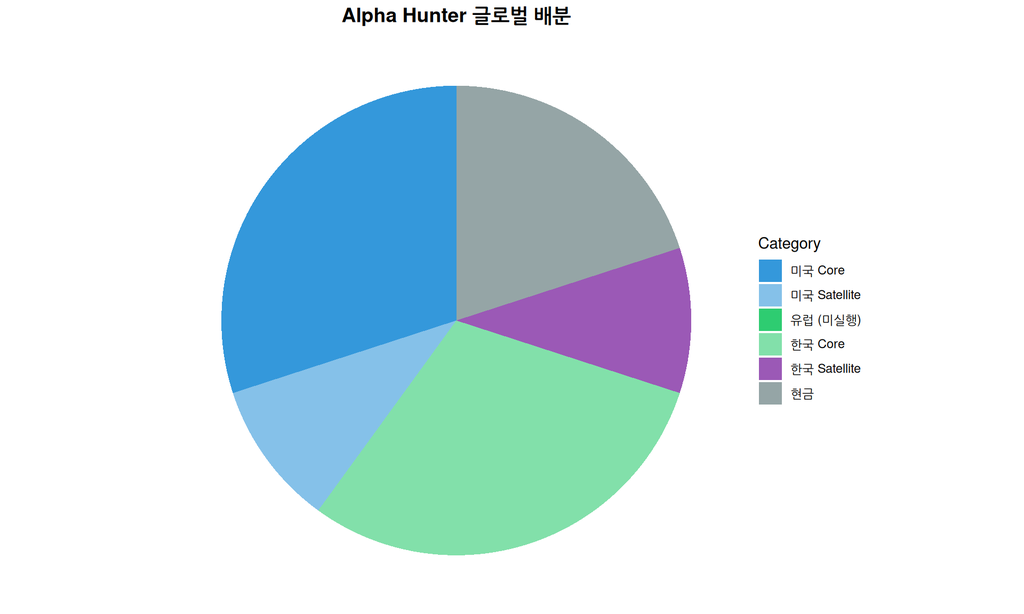

그림 3: Alpha Hunter 글로벌 배분 전략

## 실제 연금 적립식 — 현재 보류

표 4

|  | Account | ETF | Weekly | Status | Reason |
| --- | --- | --- | --- | --- | --- |
| 1 | 퇴직연금 DC | TIGER 반도체TOP10 | 50만 | 보류 | 전쟁 불확실성 |
| 2 | 퇴직연금 DC | ACE KRX금현물 | 20만 | 유일 실행 권장 | 어떤 시나리오에서도 안전 |
| 3 | 퇴직연금 DC | TIGER 코리아원자력 | 50만 | 보류 | 전쟁 불확실성 |
| 4 | 퇴직연금 DC | KoAct 코스닥액티브 | 20만 | 보류 | 전쟁 불확실성 |
| 5 | 퇴직연금 DC | KODEX 200 | 100만 | 보류 | 전쟁 불확실성 |
| 6 | 연금저축 CMA | KODEX 미국S&amp;P500 | 100만 | 보류 | 전쟁 불확실성 |
| 7 | 연금저축 CMA | KODEX 증권 | 50만 | 보류 (최고 불확실) | 금리인하 지연 가능 |
| 8 | 연금저축 CMA | KODEX 미국AI전력핵심인프라 | 50만 | 보류 | 전쟁 불확실성 |
| 9 | 연금저축 CMA | ACE 구글밸류체인 | 50만 | 보류 | 빅테크 추가 하락 가능 |

# 시나리오별 전략

표 5

|  | Scenario | Probability | Oil | Action_US | Action_KR | Action_EU |
| --- | --- | --- | --- | --- | --- | --- |
| 1 | A: 4-6월 휴전 | 46% (Polymarket) | $109→$70-80 | VOO/SOXX 추가매수, MSFT역발상 | KODEX200 적립재개, TIGER반도체 | IEUR DCA시작, Rheinmetall |
| 2 | B: 전쟁 장기화 (연말) | 24% | $100-120 유지 | XLE유지, SCHD강화 | 방산유지, 금비중확대 | 방산만 유지 |
| 3 | C: 확전/에스컬레이션 | 30% | $130+ | 현금극대화 | 전포지션 50%축소 | 전체보류 |

# 주요 일정

표 6

|  | Date | Event | Impact | Category |
| --- | --- | --- | --- | --- |
| 1 | 4/10 | 미국 CPI 발표 | 인플레 방향 → Fed 정책 | 투자 |
| 2 | 4/21 | Palisades 방화 재판 | 캘리포니아 산불 관련 | 기타 |
| 3 | 4/24 | 운전면허 갱신 | 용인 서부경찰서 18시 전 | 개인 |
| 4 | 4/25 | Fed 회의 | 금리 결정 | 투자 |
| 5 | 5/14 | HPSP FY2025 실적 | 개별주 핵심 촉매 | 투자 |
| 6 | 5월 | Fed 의장 교체 (Warsh) | 통화정책 방향 변화 | 투자 |
| 7 | 5월말 | 렛유인 강의 제출 | 이희근 프로와 공동 | 업무 |
| 8 | 6/4 | 6월 모의평가 (태림) | 재수 결정 기준점 | 가족 |

# Knowledge Base 현황

|  | Item | Count | Growth |
| --- | --- | --- | --- |
| 1 | Raw Documents | 18개 | +11 이번주 |
| 2 | Wiki Pages | 5개 | +4 이번주 |
| 3 | Skills | 3개 | +3 이번주 |
| 4 | Search Index (SQLite FTS5) | 26개 인덱싱 | +26 이번주 |
| 5 | Rust CLI (kb-search) | 1.9MB 바이너리, 0.4ms 검색 | 신규 구축 |
| 6 | Total Words | ~3,500 | +3,500 이번주 |

**이번주 하이라이트**

1. “입자설→파동설” 직관 → 2시간 만에 학술논문 → PhilSci-Archive 투고
2. Rust kb-search 구축 (Python 대비 73x 빠른 검색)
3. FinViz 스타일 퇴직/개인연금 대시보드
4. 감정 벡터 연구 카드뉴스 5장 + 음성 에세이 2편

*ALPHA HUNTER Weekly Comprehensive Report* *미국·한국·유럽 | Powered by Claude Code AI* *2026-04-05 | Not Financial Advice*